# Kids In This Economy: A Financial Feasibility Study

Joel Torres 4/22/2025

## Abstract

This project investigates the financial burden of raising children across U.S. counties using a cleaned cost of living dataset. By comparing median family income to total household costs, we assess whether families are operating at a surplus or deficit. Visualizations and regression analysis reveal that even one child can push many families into financial strain, with the deficit sharply increasing with each additional child. The findings highlight the structural economic challenges that discourage family growth and suggest that current incentives may be insufficient to reverse trends toward population decline. This analysis underscores the urgent need for policy reforms to support family sustainability in America.

## Getting Started

**Before running this document, install packages with:** install.packages(c(“tidyverse”, “ggplot2”, “scales”, “rio”))

```r
knitr::opts_chunk$set(echo = TRUE)
#Importing packages
library(rio)
library(tidyverse)
library("ggplot2")
library(scales)
```

**AND ensure the path to the data is correct**

You can download the cleaned (in SQL) data [here](https://drive.google.com/file/d/1Hs67_g3ki1b4YYeYwLMvQhrgUlAHMH2o/view?usp=sharing).

```r
#Reads in the data
col_data<-rio::import("C:\\Users\\joelt\\Downloads\\Jtorres Google Data Analytics Capstone\\cleaned_col.csv")
```

## About the Data

The dataset used in this analysis provides detailed cost of living and income information for families across U.S. counties. Each row represents a specific family structure, defined by the number of children (ranging from 0 to 4) and number of adults (either 1 or 2), along with the total family size. For each county, there are multiple entries—one for every unique combination of adult and child count—resulting in comprehensive coverage of different household scenarios. The dataset includes a breakdown of key annual expenses such as housing, food, transportation, healthcare, other necessities, childcare, and taxes, as well as the total cost of living. Median family income is also provided, allowing for analysis of remaining income (income minus total costs) and financial viability across regions and family types.

For further use in R, I first cleaned the [original data](https://www.kaggle.com/datasets/asaniczka/us-cost-of-living-dataset-3171-counties/data) by doing the following in sheets and sql: -Removing unnecessary data (area name, metro boolean, etc) -Extracting specific family count data from its original format (string to two separate integer values) -Sorted by state, county, and number of children in that order

## Remaining Income Analysis

The first metrics that caught my eye were the total cost and family income. I first looked at how many families were in a deficit or not by state.

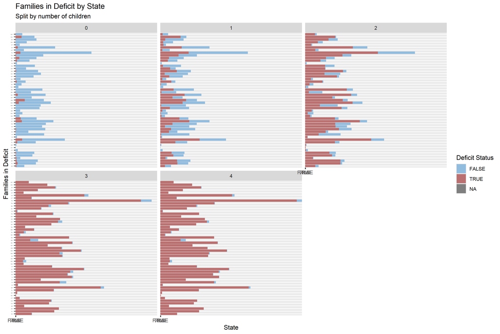

I then split it up by just the number of children and the number of parents rather than by state.

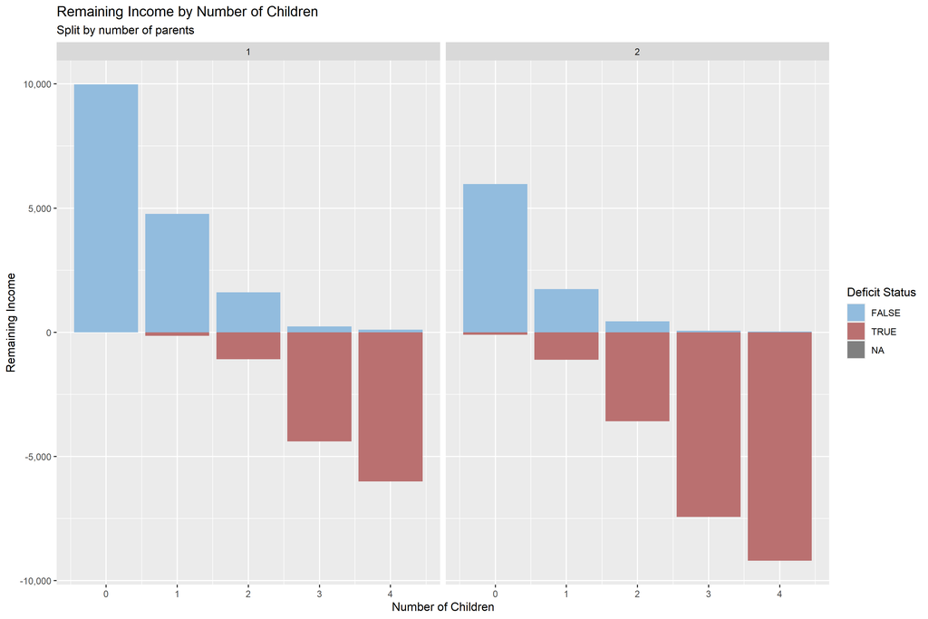

I noticed that in many of the states, having even just one child is enough to put families in the red for over a quarter of the population. What’s worse, the amount of families in financial deficit can nearly double or more with 2 children. The US has a population replacement rate of 2.1 children per women in the US, so if for the majority of Americans having 2 children remains financially unviable, the US will begin facing an issue just as hard to reverse as global warming; population collapse[^1]. You can see with the second chart how sharp the difference in remaining income can be. For many families, proposed incentives for having children are only band-aid solutions, like the $5,000 incentive proposed by President Trump per child, which will only barely cancel out the deficit of most struggling families. It is not enough to simply bring these families out of the red, financial stability does not mean living paycheck to paycheck.

I also looked at what the median incomes with the remaining incomes could tell us.

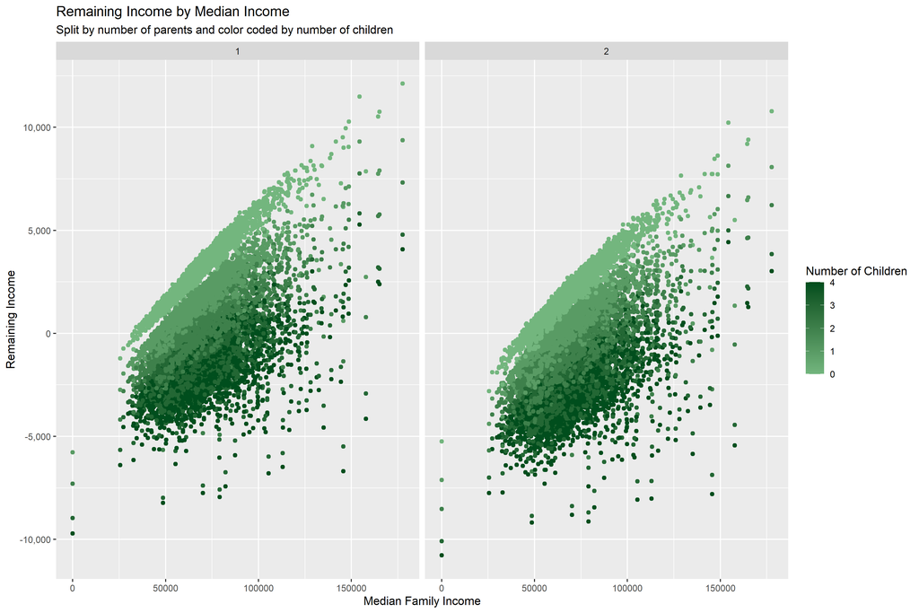

A higher income always helps when talking about issues of costs, but with the current income stagnation in the US, purchasing power is alot harder to come by. The majority of families in a deficit are in places with a median income of less than $100,000, which accounts for over 50% of Americans[^2], and with receiving a higher income being unlikely, it’s plausible to say that finances are a major deterrent towards childbirth. With the cost of living increasing with stagnant wages, Americans will do what they can to control their quality of life, and one of the first things they can control is their family size.

The last metric I looked at was the approximate effect every additional child can have on one’s finances. I fit a linear regression model to the remaining income data to examine how an extra child will affect it, finding that the remaining income was reduced by -1,251 dollars per child.

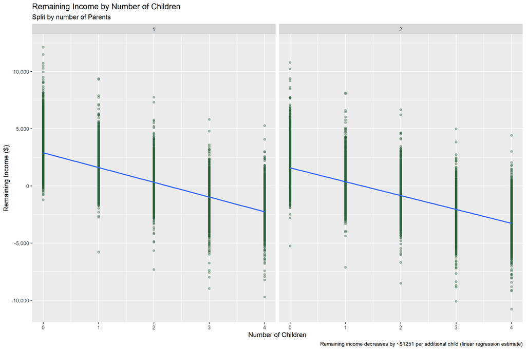

The final chart displaying the linear regression model sheds light on the impact of additional children on a family’s remaining income. This reduction, demonstrated through the linear regression line, further amplifies the financial strain that families already experience. Given the trends we observed in the other charts, where even a single child can push a family into deficit, this additional financial burden due to an extra child makes it even harder for families to manage their expenses. This pattern of diminishing income suggests that financial insecurity is not just a result of living paycheck to paycheck, but a deeper structural issue related to the economic pressures of raising children. Therefore, the model reinforces the idea that without significant financial intervention or policy change, the financial viability of having children in the U.S. will continue to deteriorate, contributing to broader societal concerns such as population collapse and economic stagnation.

[^1]: University of Pennsylvania Wharton Budget Model. (2024, March 22). *US Demographic Projections With and Without Immigration*. Retrieved from https://budgetmodel.wharton.upenn.edu/issues/2024/3/22/us-demographic-projections-with-and-without-immigration
[^2]: “Percentage distribution of household income in the U.S. 2022”, Statista, https://www.statista.com/statistics/203183/percentage-distribution-of-household-income-in-the-us/